# Bellabeat Analysis

Kasper Kurzyński

maj 2022

[figure not shown]

## **Ask**

### About the company

Bellabeat is a wellness Company headquartered in San Francisco that develops wearable computers for women. The company has offices in Zagreb, San Francisco and London. It was founded in 2013 by Sandro Mur and Urška Sršen.

### Key Stakeholders

- Urška Sršen: Cofounder and Chief Creative Officer
- Sando Mur: Cofounder and Mathematician

### Business task

Identify trends in how consumers use non-Bellabeat smart devices to apply insights into Bellabeat’s marketing strategy. The company want to find answers to particular questions:

- What are some trends in smart device usage?
- How could these trends apply to Bellabeat customers?
- How could these trends help influence Bellabeat marketing strategy?

## **Process**

To perform this analysis I will focus on using R and it’s packages.

**Packages:**

- dplyr
- ggpubr
- lubridate
- ggplot2
- plotly
- gridExtra
- forcats
- janitor

Also, from all 18 datasets I selected 3 of them, because in my opinion they can provide most useful informations to analyze trends and answer business questions.

**Datasets for analysis:**

- Daily_activity
- Daily_sleep
- weightLogInfo

### Load data and packages

```r
daily_activity <- read.csv("./project_datasets_2022/dailyActivity_merged.csv")
daily_sleep <- read.csv("./project_datasets_2022/sleepDay_merged.csv")
weight_info <- read.csv("./project_datasets_2022/weightLogInfo_merged.csv")

library(tidyverse)
library(ggpubr)
library(lubridate)
library(gridExtra)
library(forcats)
library(janitor)
library(RColorBrewer)
library(scales)
```

### Data previev

```r
head(daily_activity)
```

```
##           Id ActivityDate TotalSteps TotalDistance TrackerDistance
## 1 1503960366    4/12/2016      13162          8.50            8.50
## 2 1503960366    4/13/2016      10735          6.97            6.97
## 3 1503960366    4/14/2016      10460          6.74            6.74
## 4 1503960366    4/15/2016       9762          6.28            6.28
## 5 1503960366    4/16/2016      12669          8.16            8.16
## 6 1503960366    4/17/2016       9705          6.48            6.48
##   LoggedActivitiesDistance VeryActiveDistance ModeratelyActiveDistance
## 1                        0               1.88                     0.55
## 2                        0               1.57                     0.69
## 3                        0               2.44                     0.40
## 4                        0               2.14                     1.26
## 5                        0               2.71                     0.41
## 6                        0               3.19                     0.78
##   LightActiveDistance SedentaryActiveDistance VeryActiveMinutes
## 1                6.06                       0                25
## 2                4.71                       0                21
## 3                3.91                       0                30
## 4                2.83                       0                29
## 5                5.04                       0                36
## 6                2.51                       0                38
##   FairlyActiveMinutes LightlyActiveMinutes SedentaryMinutes Calories
## 1                  13                  328              728     1985
## 2                  19                  217              776     1797
## 3                  11                  181             1218     1776
## 4                  34                  209              726     1745
## 5                  10                  221              773     1863
## 6                  20                  164              539     1728
```

```r
glimpse(daily_activity)
```

```
## Rows: 940
## Columns: 15
## $ Id                       <dbl> 1503960366, 1503960366, 1503960366, 150396036~
## $ ActivityDate             <chr> "4/12/2016", "4/13/2016", "4/14/2016", "4/15/~
## $ TotalSteps               <int> 13162, 10735, 10460, 9762, 12669, 9705, 13019~
## $ TotalDistance            <dbl> 8.50, 6.97, 6.74, 6.28, 8.16, 6.48, 8.59, 9.8~
## $ TrackerDistance          <dbl> 8.50, 6.97, 6.74, 6.28, 8.16, 6.48, 8.59, 9.8~
## $ LoggedActivitiesDistance <dbl> 0, 0, 0, 0, 0, 0, 0, 0, 0, 0, 0, 0, 0, 0, 0, ~
## $ VeryActiveDistance       <dbl> 1.88, 1.57, 2.44, 2.14, 2.71, 3.19, 3.25, 3.5~
## $ ModeratelyActiveDistance <dbl> 0.55, 0.69, 0.40, 1.26, 0.41, 0.78, 0.64, 1.3~
## $ LightActiveDistance      <dbl> 6.06, 4.71, 3.91, 2.83, 5.04, 2.51, 4.71, 5.0~
## $ SedentaryActiveDistance  <dbl> 0, 0, 0, 0, 0, 0, 0, 0, 0, 0, 0, 0, 0, 0, 0, ~
## $ VeryActiveMinutes        <int> 25, 21, 30, 29, 36, 38, 42, 50, 28, 19, 66, 4~
## $ FairlyActiveMinutes      <int> 13, 19, 11, 34, 10, 20, 16, 31, 12, 8, 27, 21~
## $ LightlyActiveMinutes     <int> 328, 217, 181, 209, 221, 164, 233, 264, 205, ~
## $ SedentaryMinutes         <int> 728, 776, 1218, 726, 773, 539, 1149, 775, 818~
## $ Calories                 <int> 1985, 1797, 1776, 1745, 1863, 1728, 1921, 203~
```

```r
head(daily_sleep)
```

```
##           Id              SleepDay TotalSleepRecords TotalMinutesAsleep
## 1 1503960366 4/12/2016 12:00:00 AM                 1                327
## 2 1503960366 4/13/2016 12:00:00 AM                 2                384
## 3 1503960366 4/15/2016 12:00:00 AM                 1                412
## 4 1503960366 4/16/2016 12:00:00 AM                 2                340
## 5 1503960366 4/17/2016 12:00:00 AM                 1                700
## 6 1503960366 4/19/2016 12:00:00 AM                 1                304
##   TotalTimeInBed
## 1            346
## 2            407
## 3            442
## 4            367
## 5            712
## 6            320
```

```r
glimpse(daily_sleep)
```

```
## Rows: 413
## Columns: 5
## $ Id                 <dbl> 1503960366, 1503960366, 1503960366, 1503960366, 150~
## $ SleepDay           <chr> "4/12/2016 12:00:00 AM", "4/13/2016 12:00:00 AM", "~
## $ TotalSleepRecords  <int> 1, 2, 1, 2, 1, 1, 1, 1, 1, 1, 1, 1, 1, 1, 1, 1, 1, ~
## $ TotalMinutesAsleep <int> 327, 384, 412, 340, 700, 304, 360, 325, 361, 430, 2~
## $ TotalTimeInBed     <int> 346, 407, 442, 367, 712, 320, 377, 364, 384, 449, 3~
```

```r
head(weight_info)
```

```
##           Id                  Date WeightKg WeightPounds Fat   BMI
## 1 1503960366  5/2/2016 11:59:59 PM     52.6     115.9631  22 22.65
## 2 1503960366  5/3/2016 11:59:59 PM     52.6     115.9631  NA 22.65
## 3 1927972279  4/13/2016 1:08:52 AM    133.5     294.3171  NA 47.54
## 4 2873212765 4/21/2016 11:59:59 PM     56.7     125.0021  NA 21.45
## 5 2873212765 5/12/2016 11:59:59 PM     57.3     126.3249  NA 21.69
## 6 4319703577 4/17/2016 11:59:59 PM     72.4     159.6147  25 27.45
##   IsManualReport        LogId
## 1           True 1.462234e+12
## 2           True 1.462320e+12
## 3          False 1.460510e+12
## 4           True 1.461283e+12
## 5           True 1.463098e+12
## 6           True 1.460938e+12
```

```r
glimpse(weight_info)
```

```
## Rows: 67
## Columns: 8
## $ Id             <dbl> 1503960366, 1503960366, 1927972279, 2873212765, 2873212~
## $ Date           <chr> "5/2/2016 11:59:59 PM", "5/3/2016 11:59:59 PM", "4/13/2~
## $ WeightKg       <dbl> 52.6, 52.6, 133.5, 56.7, 57.3, 72.4, 72.3, 69.7, 70.3, ~
## $ WeightPounds   <dbl> 115.9631, 115.9631, 294.3171, 125.0021, 126.3249, 159.6~
## $ Fat            <int> 22, NA, NA, NA, NA, 25, NA, NA, NA, NA, NA, NA, NA, NA,~
## $ BMI            <dbl> 22.65, 22.65, 47.54, 21.45, 21.69, 27.45, 27.38, 27.25,~
## $ IsManualReport <chr> "True", "True", "False", "True", "True", "True", "True"~
## $ LogId          <dbl> 1.462234e+12, 1.462320e+12, 1.460510e+12, 1.461283e+12,~
```

### Check of distinct values and duplicated

```r
n_distinct(daily_activity$Id)
```

```
## [1] 33
```

```r
n_distinct(daily_sleep$Id)
```

```
## [1] 24
```

```r
n_distinct(weight_info$Id)
```

```
## [1] 8
```

```r
sum(duplicated(daily_activity))
```

```
## [1] 0
```

```r
sum(duplicated(daily_sleep))
```

```
## [1] 3
```

```r
sum(duplicated(weight_info))
```

```
## [1] 0
```

### Removing duplicates

```r
daily_sleep <- daily_sleep %>%
  distinct()
sum(duplicated(daily_sleep))
```

```
## [1] 0
```

### Check of NA values and removing if exists

```r
sum(is.na(daily_activity))
```

```
## [1] 0
```

```r
sum(is.na(daily_sleep))
```

```
## [1] 0
```

```r
sum(is.na(weight_info))
```

```
## [1] 65
```

```r
weight_info$Fat <- NULL
sum(is.na(weight_info))
```

```
## [1] 0
```

### Changing type of variables and adding new ones

```r
daily_activity <- daily_activity %>%
  rename(date = ActivityDate) %>%
  mutate(date = as_date(date, format = "%m/%d/%Y"))

daily_sleep <- daily_sleep %>%
  rename(date = SleepDay) %>%
  mutate(date = as_date(date,format ="%m/%d/%Y"))

weight_info <- weight_info %>%
  rename(date = Date) %>%
  mutate(date = as_date(date,format ="%m/%d/%Y"))

daily_activity <- clean_names(daily_activity)
daily_sleep <- clean_names(daily_sleep)
weight_info <- clean_names(weight_info)

daily_activity$day <- wday(daily_activity$date, label=TRUE)
daily_sleep$day <- wday(daily_sleep$date, label=TRUE)

daily_activity$day <- as.factor(daily_activity$day)
daily_sleep$day <- as.factor(daily_sleep$day)

daily_activity$day <- substr(daily_activity$day,1,1)
daily_activity$day <- recode(daily_activity$day, n = "Sunday",
                                p = "Monday",
                                w = "Tuesday",
                                ś = "Wednesday",
                                c = "Thursday",
                                p = "Friday",
                                s = "Saturday")

daily_sleep$day <- substr(daily_sleep$day,1,1)
daily_sleep$day <- recode(daily_sleep$day, n = "Sunday",
                              p = "Monday",
                              w = "Tuesday",
                              ś = "Wednesday",
                              c = "Thursday",
                              p = "Friday",
                              s = "Saturday")
```

### Merging into final dataset

```r
merge_data <- merge(merge(daily_activity, daily_sleep, by = c('id', 'date'), all = TRUE),
                    weight_info, by = c('id', 'date'), all = TRUE)

summary(merge_data)
```

```
##        id                 date             total_steps    total_distance
##  Min.   :1.504e+09   Min.   :2016-04-12   Min.   :    0   Min.   : 0.000
##  1st Qu.:2.320e+09   1st Qu.:2016-04-19   1st Qu.: 3790   1st Qu.: 2.620
##  Median :4.445e+09   Median :2016-04-26   Median : 7406   Median : 5.245
##  Mean   :4.855e+09   Mean   :2016-04-26   Mean   : 7638   Mean   : 5.490
##  3rd Qu.:6.962e+09   3rd Qu.:2016-05-04   3rd Qu.:10727   3rd Qu.: 7.713
##  Max.   :8.878e+09   Max.   :2016-05-12   Max.   :36019   Max.   :28.030
##
##  tracker_distance logged_activities_distance very_active_distance
##  Min.   : 0.000   Min.   :0.0000             Min.   : 0.000
##  1st Qu.: 2.620   1st Qu.:0.0000             1st Qu.: 0.000
##  Median : 5.245   Median :0.0000             Median : 0.210
##  Mean   : 5.475   Mean   :0.1082             Mean   : 1.503
##  3rd Qu.: 7.710   3rd Qu.:0.0000             3rd Qu.: 2.053
##  Max.   :28.030   Max.   :4.9421             Max.   :21.920
##
##  moderately_active_distance light_active_distance sedentary_active_distance
##  Min.   :0.0000             Min.   : 0.000        Min.   :0.000000
##  1st Qu.:0.0000             1st Qu.: 1.945        1st Qu.:0.000000
##  Median :0.2400             Median : 3.365        Median :0.000000
##  Mean   :0.5675             Mean   : 3.341        Mean   :0.001606
##  3rd Qu.:0.8000             3rd Qu.: 4.782        3rd Qu.:0.000000
##  Max.   :6.4800             Max.   :10.710        Max.   :0.110000
##
##  very_active_minutes fairly_active_minutes lightly_active_minutes
##  Min.   :  0.00      Min.   :  0.00        Min.   :  0.0
##  1st Qu.:  0.00      1st Qu.:  0.00        1st Qu.:127.0
##  Median :  4.00      Median :  6.00        Median :199.0
##  Mean   : 21.16      Mean   : 13.56        Mean   :192.8
##  3rd Qu.: 32.00      3rd Qu.: 19.00        3rd Qu.:264.0
##  Max.   :210.00      Max.   :143.00        Max.   :518.0
##
##  sedentary_minutes    calories       day.x           total_sleep_records
##  Min.   :   0.0    Min.   :   0   Length:940         Min.   :1.000
##  1st Qu.: 729.8    1st Qu.:1828   Class :character   1st Qu.:1.000
##  Median :1057.5    Median :2134   Mode  :character   Median :1.000
##  Mean   : 991.2    Mean   :2304                      Mean   :1.119
##  3rd Qu.:1229.5    3rd Qu.:2793                      3rd Qu.:1.000
##  Max.   :1440.0    Max.   :4900                      Max.   :3.000
##                                                      NA's   :530
##  total_minutes_asleep total_time_in_bed    day.y             weight_kg
##  Min.   : 58.0        Min.   : 61.0     Length:940         Min.   : 52.60
##  1st Qu.:361.0        1st Qu.:403.8     Class :character   1st Qu.: 61.40
##  Median :432.5        Median :463.0     Mode  :character   Median : 62.50
##  Mean   :419.2        Mean   :458.5                        Mean   : 72.04
##  3rd Qu.:490.0        3rd Qu.:526.0                        3rd Qu.: 85.05
##  Max.   :796.0        Max.   :961.0                        Max.   :133.50
##  NA's   :530          NA's   :530                          NA's   :873
##  weight_pounds        bmi        is_manual_report       log_id
##  Min.   :116.0   Min.   :21.45   Length:940         Min.   :1.460e+12
##  1st Qu.:135.4   1st Qu.:23.96   Class :character   1st Qu.:1.461e+12
##  Median :137.8   Median :24.39   Mode  :character   Median :1.462e+12
##  Mean   :158.8   Mean   :25.19                      Mean   :1.462e+12
##  3rd Qu.:187.5   3rd Qu.:25.56                      3rd Qu.:1.462e+12
##  Max.   :294.3   Max.   :47.54                      Max.   :1.463e+12
##  NA's   :873     NA's   :873                        NA's   :873
```

```r
final_data <- merge_data %>%
  select(-c("log_id", "is_manual_report", "weight_pounds",
            "total_sleep_records", "tracker_distance", "logged_activities_distance")) %>%
  rename(day_activity = day.x,
         day_sleep = day.y) %>%
  mutate(day_activity = factor(day_activity),
         day_sleep = factor(day_sleep))

final_data$id <- as.factor(final_data$id)
```

### Show final dataset

```r
head(final_data)
```

```
##           id       date total_steps total_distance very_active_distance
## 1 1503960366 2016-04-12       13162           8.50                 1.88
## 2 1503960366 2016-04-13       10735           6.97                 1.57
## 3 1503960366 2016-04-14       10460           6.74                 2.44
## 4 1503960366 2016-04-15        9762           6.28                 2.14
## 5 1503960366 2016-04-16       12669           8.16                 2.71
## 6 1503960366 2016-04-17        9705           6.48                 3.19
##   moderately_active_distance light_active_distance sedentary_active_distance
## 1                       0.55                  6.06                         0
## 2                       0.69                  4.71                         0
## 3                       0.40                  3.91                         0
## 4                       1.26                  2.83                         0
## 5                       0.41                  5.04                         0
## 6                       0.78                  2.51                         0
##   very_active_minutes fairly_active_minutes lightly_active_minutes
```

[output cut: 20 more lines]

```r
glimpse(final_data)
```

```
## Rows: 940
## Columns: 19
## $ id                         <fct> 1503960366, 1503960366, 1503960366, 1503960~
## $ date                       <date> 2016-04-12, 2016-04-13, 2016-04-14, 2016-0~
## $ total_steps                <int> 13162, 10735, 10460, 9762, 12669, 9705, 130~
## $ total_distance             <dbl> 8.50, 6.97, 6.74, 6.28, 8.16, 6.48, 8.59, 9~
## $ very_active_distance       <dbl> 1.88, 1.57, 2.44, 2.14, 2.71, 3.19, 3.25, 3~
## $ moderately_active_distance <dbl> 0.55, 0.69, 0.40, 1.26, 0.41, 0.78, 0.64, 1~
## $ light_active_distance      <dbl> 6.06, 4.71, 3.91, 2.83, 5.04, 2.51, 4.71, 5~
## $ sedentary_active_distance  <dbl> 0, 0, 0, 0, 0, 0, 0, 0, 0, 0, 0, 0, 0, 0, 0~
## $ very_active_minutes        <int> 25, 21, 30, 29, 36, 38, 42, 50, 28, 19, 66,~
## $ fairly_active_minutes      <int> 13, 19, 11, 34, 10, 20, 16, 31, 12, 8, 27, ~
## $ lightly_active_minutes     <int> 328, 217, 181, 209, 221, 164, 233, 264, 205~
## $ sedentary_minutes          <int> 728, 776, 1218, 726, 773, 539, 1149, 775, 8~
## $ calories                   <int> 1985, 1797, 1776, 1745, 1863, 1728, 1921, 2~
## $ day_activity               <fct> Tuesday, Wednesday, Thursday, Monday, Satur~
## $ total_minutes_asleep       <int> 327, 384, NA, 412, 340, 700, NA, 304, 360, ~
## $ total_time_in_bed          <int> 346, 407, NA, 442, 367, 712, NA, 320, 377, ~
## $ day_sleep                  <fct> Tuesday, Wednesday, NA, Monday, Saturday, S~
## $ weight_kg                  <dbl> NA, NA, NA, NA, NA, NA, NA, NA, NA, NA, NA,~
## $ bmi                        <dbl> NA, NA, NA, NA, NA, NA, NA, NA, NA, NA, NA,~
```

```r
summary(final_data)
```

```
##           id           date             total_steps    total_distance
##  1503960366: 31   Min.   :2016-04-12   Min.   :    0   Min.   : 0.000
##  1624580081: 31   1st Qu.:2016-04-19   1st Qu.: 3790   1st Qu.: 2.620
##  1844505072: 31   Median :2016-04-26   Median : 7406   Median : 5.245
##  1927972279: 31   Mean   :2016-04-26   Mean   : 7638   Mean   : 5.490
##  2022484408: 31   3rd Qu.:2016-05-04   3rd Qu.:10727   3rd Qu.: 7.713
##  2026352035: 31   Max.   :2016-05-12   Max.   :36019   Max.   :28.030
##  (Other)   :754
##  very_active_distance moderately_active_distance light_active_distance
##  Min.   : 0.000       Min.   :0.0000             Min.   : 0.000
##  1st Qu.: 0.000       1st Qu.:0.0000             1st Qu.: 1.945
##  Median : 0.210       Median :0.2400             Median : 3.365
##  Mean   : 1.503       Mean   :0.5675             Mean   : 3.341
##  3rd Qu.: 2.053       3rd Qu.:0.8000             3rd Qu.: 4.782
##  Max.   :21.920       Max.   :6.4800             Max.   :10.710
##
##  sedentary_active_distance very_active_minutes fairly_active_minutes
##  Min.   :0.000000          Min.   :  0.00      Min.   :  0.00
##  1st Qu.:0.000000          1st Qu.:  0.00      1st Qu.:  0.00
##  Median :0.000000          Median :  4.00      Median :  6.00
##  Mean   :0.001606          Mean   : 21.16      Mean   : 13.56
##  3rd Qu.:0.000000          3rd Qu.: 32.00      3rd Qu.: 19.00
##  Max.   :0.110000          Max.   :210.00      Max.   :143.00
##
##  lightly_active_minutes sedentary_minutes    calories       day_activity
##  Min.   :  0.0          Min.   :   0.0    Min.   :   0   Monday   :246
##  1st Qu.:127.0          1st Qu.: 729.8    1st Qu.:1828   Saturday :124
##  Median :199.0          Median :1057.5    Median :2134   Sunday   :121
##  Mean   :192.8          Mean   : 991.2    Mean   :2304   Thursday :147
##  3rd Qu.:264.0          3rd Qu.:1229.5    3rd Qu.:2793   Tuesday  :152
##  Max.   :518.0          Max.   :1440.0    Max.   :4900   Wednesday:150
##
##  total_minutes_asleep total_time_in_bed     day_sleep     weight_kg
##  Min.   : 58.0        Min.   : 61.0     Monday   :103   Min.   : 52.60
##  1st Qu.:361.0        1st Qu.:403.8     Saturday : 57   1st Qu.: 61.40
##  Median :432.5        Median :463.0     Sunday   : 55   Median : 62.50
##  Mean   :419.2        Mean   :458.5     Thursday : 64   Mean   : 72.04
##  3rd Qu.:490.0        3rd Qu.:526.0     Tuesday  : 65   3rd Qu.: 85.05
##  Max.   :796.0        Max.   :961.0     Wednesday: 66   Max.   :133.50
##  NA's   :530          NA's   :530       NA's     :530   NA's   :873
##       bmi
##  Min.   :21.45
##  1st Qu.:23.96
##  Median :24.39
##  Mean   :25.19
##  3rd Qu.:25.56
##  Max.   :47.54
##  NA's   :873
```

## **Analyze & Share**

### Checking the assumptions about the normality of the distribution

Variables: *total_steps*, *calories*, *total_time_in_bed* and *total_minutes_asleep* don’t have normal distrubution. Such conclusion can be made of the basis of the p-value in the shapiro.wilk test. For this reason, the Spearman coefficient will be used to calculate the correlation, while in the case of a median comparison between the groups, the Kruskal Wallis test will be conducted.

```r
scoreShapiroSteps <- shapiro.test(final_data$total_steps)
print(scoreShapiroSteps)
```

```
##
##  Shapiro-Wilk normality test
##
## data:  final_data$total_steps
## W = 0.9619, p-value = 6.079e-15
```

```r
scoreShapiroCalories <- shapiro.test(final_data$calories)
print(scoreShapiroCalories)
```

```
##
##  Shapiro-Wilk normality test
##
## data:  final_data$calories
## W = 0.96968, p-value = 4.336e-13
```

```r
scoreShapiroBed <- shapiro.test(final_data$total_time_in_bed)
print(scoreShapiroBed)
```

```
##
##  Shapiro-Wilk normality test
##
## data:  final_data$total_time_in_bed
## W = 0.91406, p-value = 1.608e-14
```

```r
scoreShapiroAsleep <- shapiro.test(final_data$total_minutes_asleep)
print(scoreShapiroAsleep)
```

```
##
##  Shapiro-Wilk normality test
##
## data:  final_data$total_minutes_asleep
## W = 0.95162, p-value = 2.48e-10
```

### Scatter plots

According to scatter plots, we can observe positive and statistically significant correlations between variables *calories* and *total_steps* and *total_minutes_asleep* and *total_time_in_bed*.

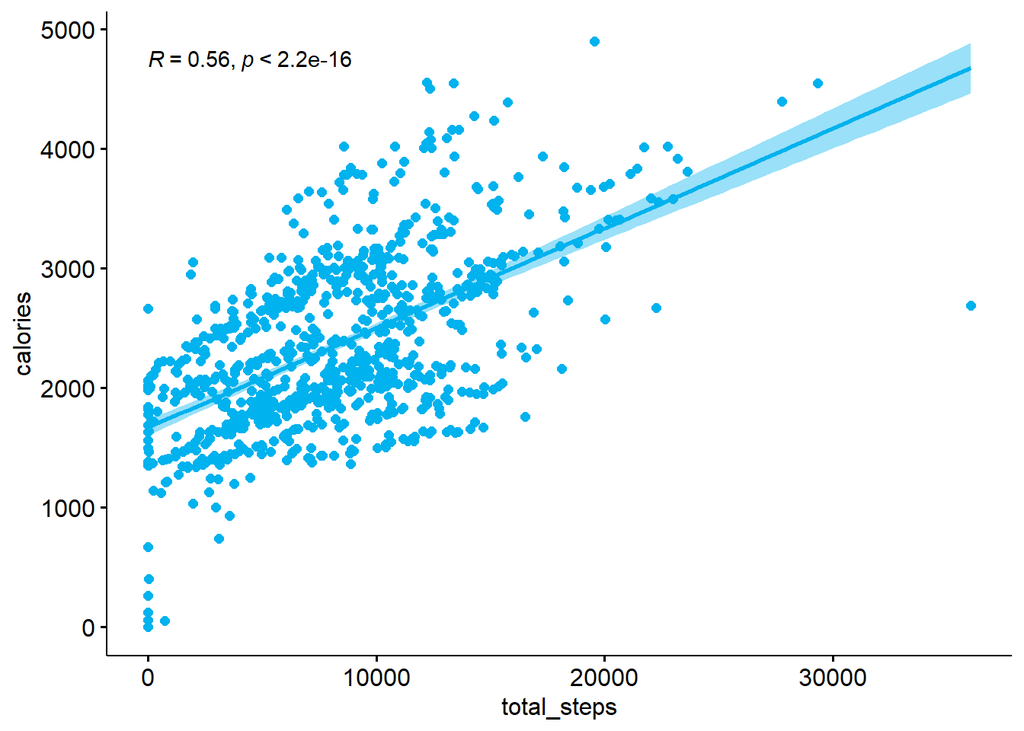

```r
ggscatter(final_data, x = "total_steps", y = "calories",
          conf.int = TRUE,
          add = "reg.line",
          color = "deepskyblue2") + stat_cor(method = "spearman")
```

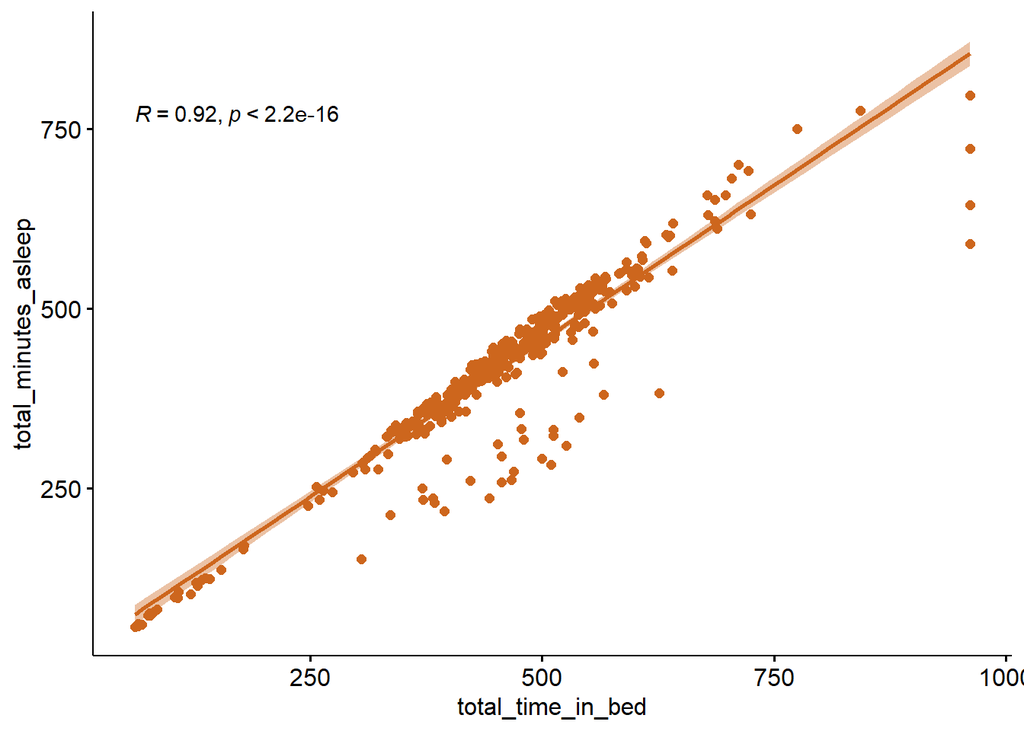

```r
ggscatter(final_data, x = "total_time_in_bed", y = "total_minutes_asleep",
          conf.int = TRUE,
          add = "reg.line",
          color = "chocolate3") + stat_cor(method = "spearman")
```

### Bar plot

On this bar plot you can see that the highest percentage of participants’ daily activity is sedentary or light activity. High activity accounted for less than 2% of the total activity

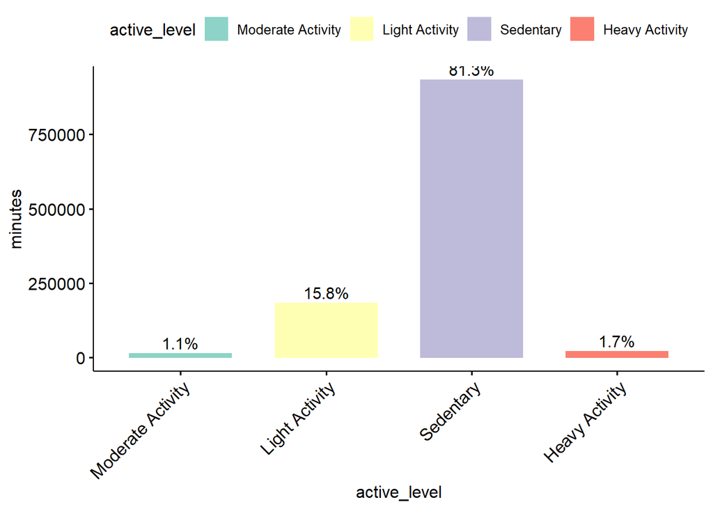

```r
sumMin <- final_data %>%
  select(very_active_minutes,
         fairly_active_minutes,
         lightly_active_minutes,
         sedentary_minutes) %>%
  summarise(across(everything(), list(sum))) %>%
  gather(active_level, minutes) %>%
  mutate(active_level = factor(active_level,
                               labels = c('Moderate Activity','Light Activity',
                                          'Sedentary','Heavy Activity'))) %>%
  mutate(percentage = percent(round(minutes / sum(minutes),3)))


ggbarplot(sumMin, x = "active_level", y = "minutes",
          color = "active_level", fill = "active_level", palette = "Set3",
          label = c("1.7%", "1.1%", "15.8%", "81.3%"), lab.col = "black", x.text.angle = 45)
```

The second graph shows what percentage of the *total distance* was represented by the participants’ activity levels.

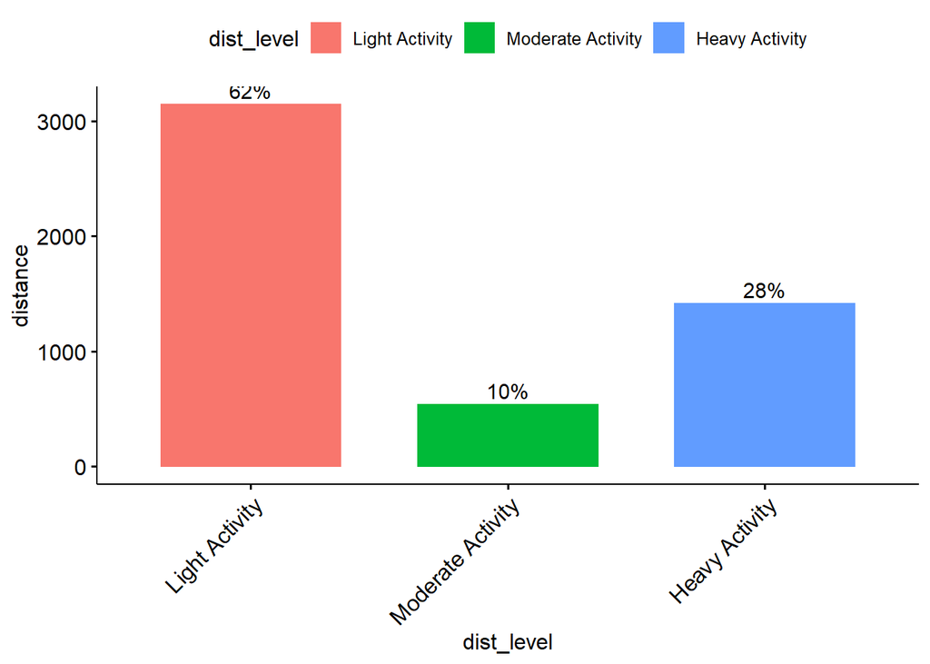

```r
sumDist <- final_data %>%
  select(very_active_distance,
         moderately_active_distance,
         light_active_distance) %>%
  summarise(across(everything(), list(sum))) %>%
  gather(dist_level, distance) %>%
  mutate(dist_level = factor(dist_level,
                               labels = c('Light Activity', 'Moderate Activity', 'Heavy Activity'))) %>%
  mutate(percentage = percent(round(distance / sum(distance),3)))

ggbarplot(sumDist, x = "dist_level", y = "distance",
          color = "dist_level", fill = "dist_level", palette = "PiYg",
          label = c("28%", "10%", "62%"), lab.col = "black", x.text.angle = 45)
```

### Scatter plots for aggregated data

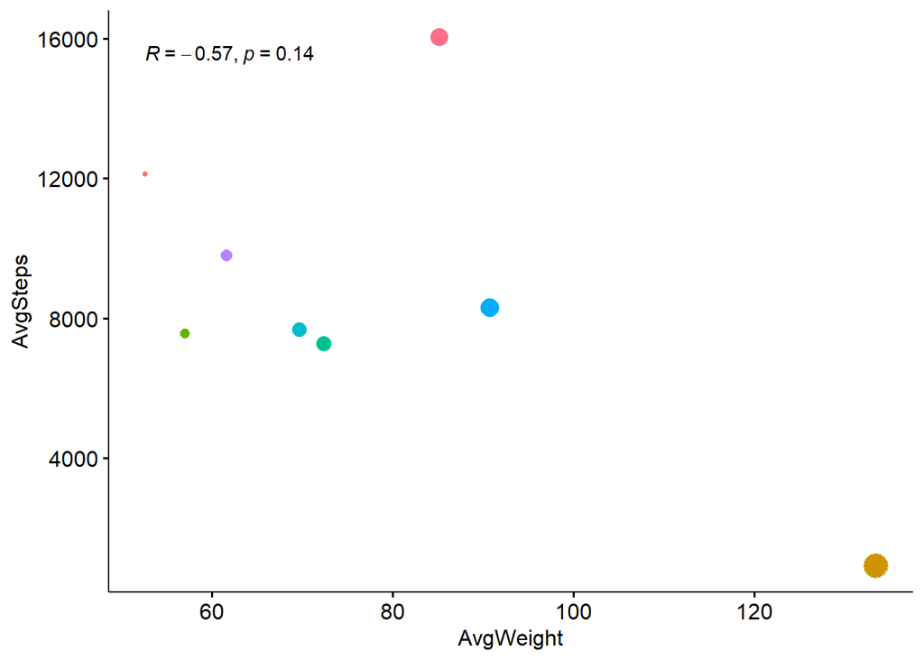

```r
idAvg <- final_data %>%
  group_by(id) %>%
  summarise(AvgSteps = mean(total_steps),
            AvgCalor = mean(calories),
            AvgWeight = mean(weight_kg, na.rm=T))


ggscatter(idAvg, x = "AvgWeight", y = "AvgSteps",
          size = "AvgWeight", color = "id") +
  stat_cor(method = "pearson") + rremove("legend")
```

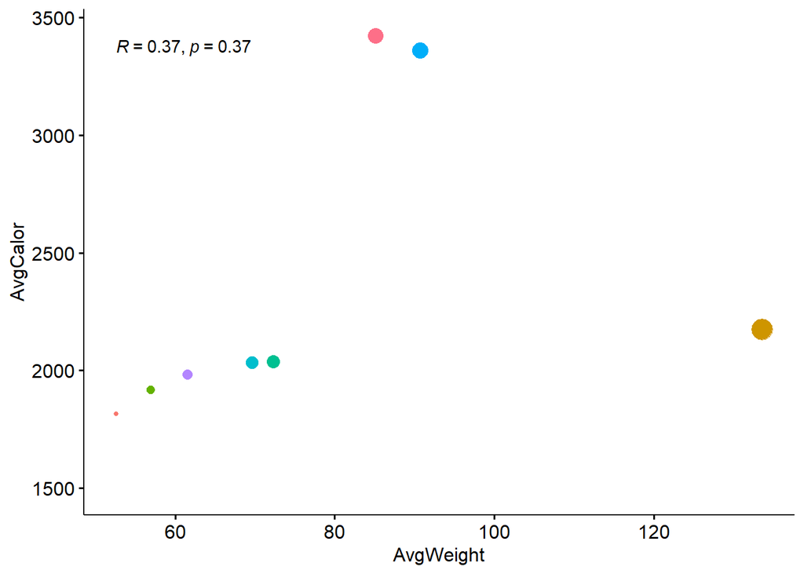

```r
ggscatter(idAvg, x = "AvgWeight", y = "AvgCalor",
          size = "AvgWeight", color = "id") +
  stat_cor(method = "pearson") + rremove("legend")
```

### Boxplots

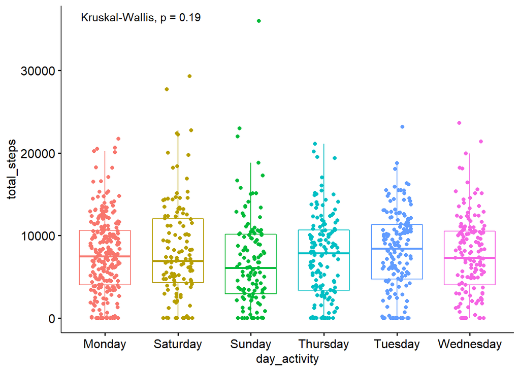

```r
ggboxplot(final_data, x = "day_activity", y = "total_steps",
          color = "day_activity", palette = "BrBg",
          add = "jitter") + stat_compare_means() + rremove("legend")
```

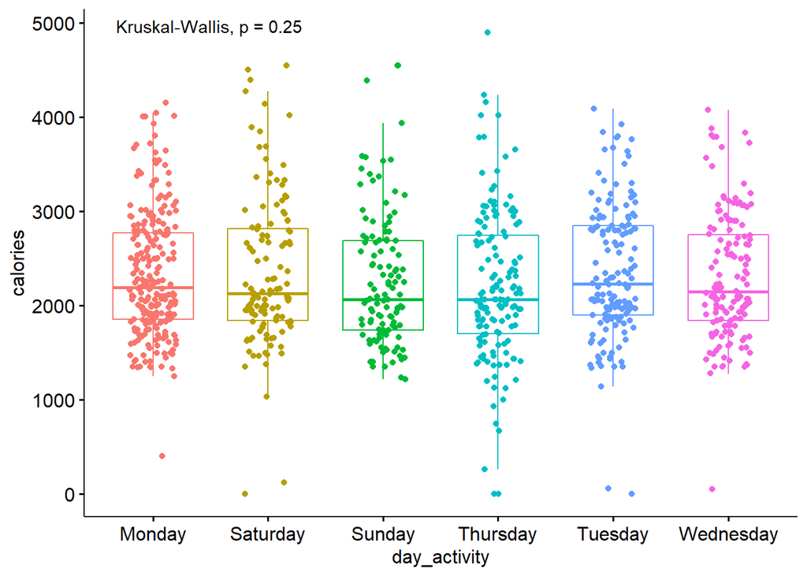

```r
ggboxplot(final_data, x = "day_activity", y = "calories",
          color = "day_activity", palette = "BrBg",
          add = "jitter") + stat_compare_means() + rremove("legend")
```

### Histograms with scatterplot

These histograms shows distrubution of variables: *total_time_in_bed* and *total_minutes_asleep*. Also, scatter plot was made to determine, whether there is the correlation between variables: *total_minutes_asleep* and *total_steps*.

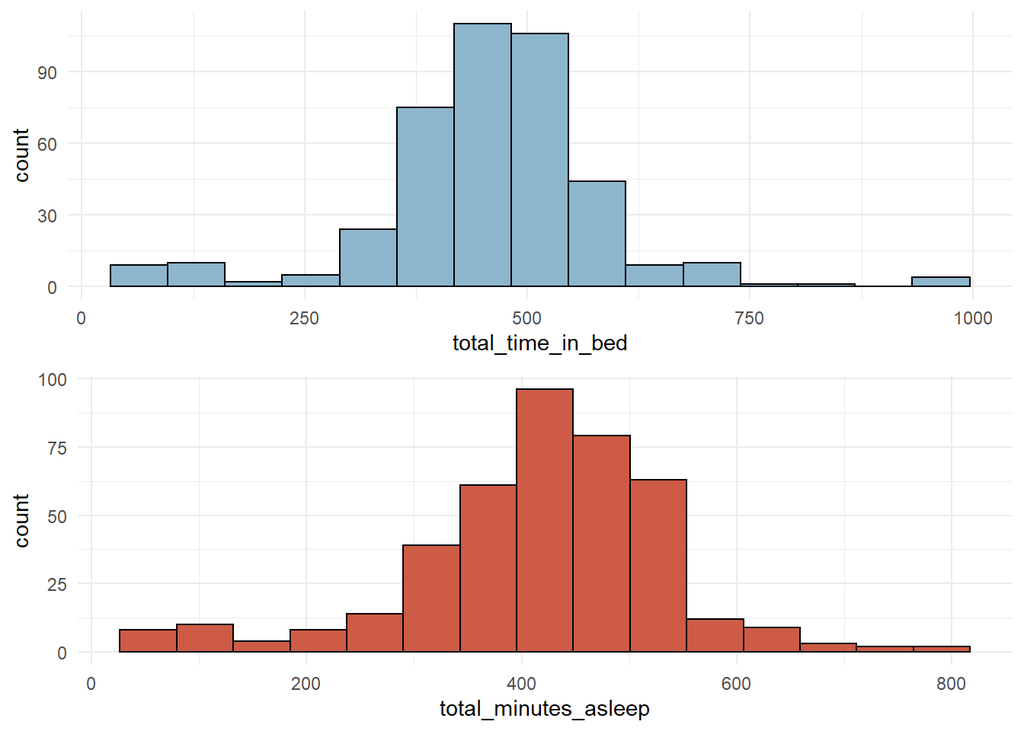

```r
histbed <- ggplot(final_data, aes(x = total_time_in_bed)) + geom_histogram(bins = 15, fill = "lightskyblue3", color = "black") +
  theme_minimal()
histasleep <- ggplot(final_data, aes(x = total_minutes_asleep)) + geom_histogram(bins = 15, fill = "coral3", color = "black") +
  theme_minimal()
grid.arrange(histbed, histasleep)
```

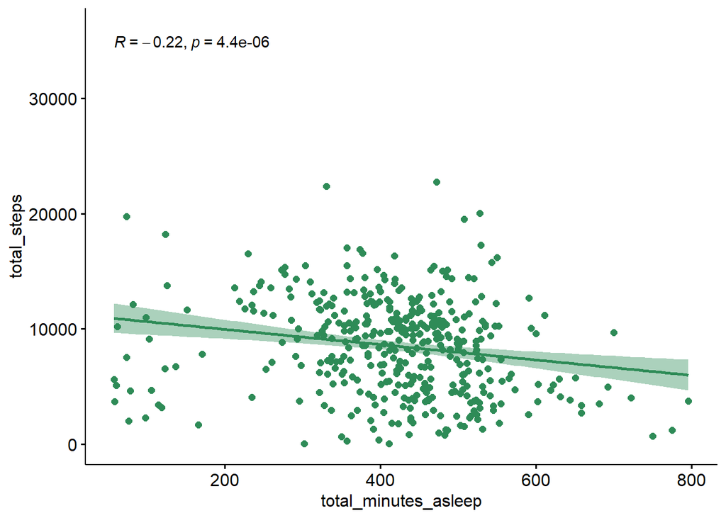

```r
ggscatter(final_data, x = "total_minutes_asleep", y = "total_steps",
          conf.int = TRUE,
          add = "reg.line",
          color = "seagreen4") + stat_cor(method = "spearman")
```

## **Act**

On the basis of the above data and graphs, certain conclusions can be drawn.

Conclusions:

- If users want to lose weight, it’s probably a good idea to control daily calorie consumption and impoving daily activity. Bellabeat should add notifications to control both values.
- To improve users sleep, Bellabeat should consider using app notifications to go to bed.
- Adding notifications to remind users to do more steps daily.